# SpatialTreeP — restitution

Réchauffement global, réponses locales

Dynamique des lisières forestières supérieures dans les Pyrénées orientales :  
Apports du projet **SpatialTreeP**

**Thierry Feuillet · Université de Caen Normandie, UMR IDEES** · pour l’ensemble du consortium

**IDEES, Université de Caen Normandie** Thierry Feuillet, Pablo Moreno-Garcia, Léa Keurinck, Roman Lagalis

**LADYSS, Université Paris 8** Johan Milian, Bénédicte MacGregor

**Pléiade, Université Sorbonne Paris Nord** Frédéric Alexandre, Déborah Birre *(aujourd’hui FRB-CESAB)*

**DYNAFOR, INRAE / Toulouse INP** Luc Barbaro, David Sheeren, François Calatayud, Thierry Gaubert

**CEFE, CNRS Montpellier** Xavier Morin

**SETE, CNRS Moulis** Maxime Cauchoix, David Funosas

**Science-Po Toulouse** Steve Hagimont

**PRODIG et CIST, Université Paris Cité** Paul Passy, Olivier Theureaux

**ESPACE, Université d’Avignon** Matthieu Vignal

**Universidad de Zaragoza (IUCA)** Roberto Serrano-Notivoli

**Philipps-Universität Marburg** Maaike Y. Bader

**CESBIO, INRAE** Vincent Thierion, Valentine Bellet

**UPPA** Mathilde Lamothe

[figure not shown]

# 1. Introduction

Pourquoi les lisières ne montent-elles pas toutes ?

## Un résultat qui ne colle pas au récit

Le récit attendu : le climat se réchauffe, les forêts montent uniformément.

Ce que l’on observe dans les Pyrénées orientales, entre les années 1950 et 2015 :

+39 m décalage altitudinal moyen

−212 / +308 amplitude des décalages observés, en mètres

+2,1 °C hausse de Tmax entre 1950–84 et 1985–2020, sur tous les sites

Un forçage climatique quasi homogène, des réponses forestières qui vont de la régression franche à la progression de 300 mètres. Le climat seul ne peut pas être l’explication.

## Dans les Pyrénées, la lisière est d’abord un objet pastoral

Des siècles de pâturage, d’écobuage et de coupes ont **abaissé les limites forestières de plusieurs centaines de mètres** et modifié la composition : feuillus en bas, *Pinus uncinata* seulement en haut.

Puis, à partir des années 1950, la déprise : dans la partie ouest de la zone d’étude, la population chute de **54 %** en soixante ans.

La lisière que nous mesurons en 1955 n’est donc pas une lisière climatique, mais un état hérité.

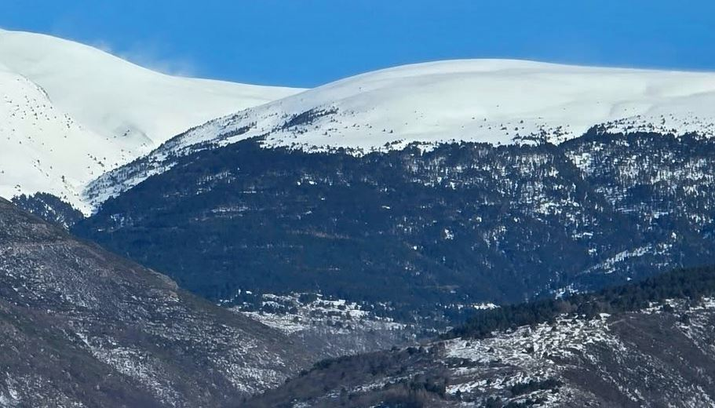

Lisière “anthropique” largement héritée des pratiques pastorales, massif du Puigmal (PO)

## Les questions du projet

### Question principale

La hiérarchie des facteurs de changement — climat, usages, caractéristiques de site — est-elle **spatialement structurée** ?

Si oui, il faut un cadre spatialement explicite, qui autorise les relations à varier dans l’espace.

### Question secondaire

La dynamique de la lisière modifie-t-elle les **communautés qui l’habitent** ?

Question périphérique dans le projet initial, devenue centrale au fil du projet.

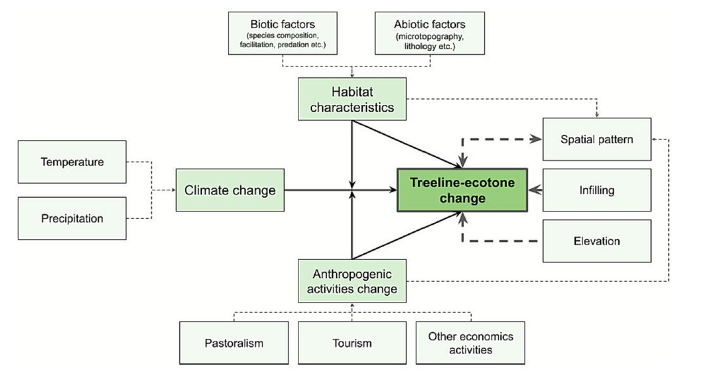

Cadre théorique des déterminants de la dynamique forestière supérieure, Birre *et al.* 2026

# 2. Méthodologie

## Le terrain et les données

- 648 sites répartis le long de l’écotone, Ariège et Pyrénées-Orientales
- Placettes de 600 × 200 m perpendiculaires à la pente
- Orthophotos IGN à 50 cm : 1953–1956 et 2015–2016
- Segmentation puis classification supervisée Random Forest, corrigée visuellement
- Précision globale 92 %, kappa 0,84–0,88
- 94 variables candidates : climat interpolé depuis 1 500 stations, MNT à 1 m, lithologie, usages, protection

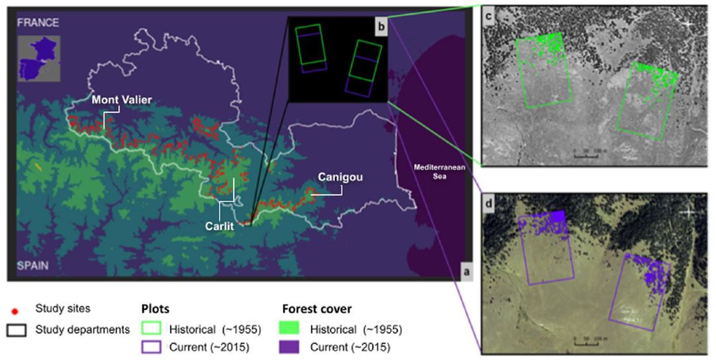

Échantillonnage des placettes, Birre *et al.* 2023

## La dynamique de la lisère n’est pas une variable, mais trois

### Décalage altitudinal alt

Variation de l’altitude des cinq pixels forestiers les plus hauts.

### Infilling infill

Variation de la proportion de pixels forestiers.

### Forme forme

Variation de la configuration spatiale : diffus, îlots, discret.

Ces trois dimensions ne se déduisent pas les unes des autres. La quasi-totalité de la littérature n’en mesure qu’une, la première.

## Quantifier la forme : un protocole reproductible forme

1. 33 métriques paysagères par placette (agrégation, aire, cœur, forme)
2. Classification hiérarchique → trois types : diffus, îlots, discret

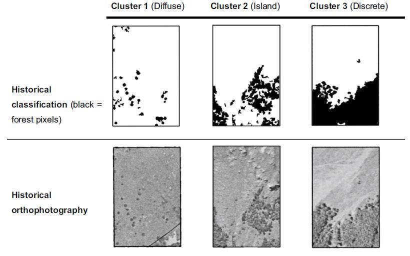

Forme des lisières, Birre *et al.* 2023

Une mesure continue et directionnelle du changement de forme, applicable partout où l’on dispose de deux dates d’imagerie.

Birre, Feuillet, Lagalis *et al.* (2023), *Landscape Ecology* 38, 779–796.

# 3. Résultats

Trois dimensions, trois jeux de facteurs, une géographie.

## La forme change, massivement forme

52 % des 648 sites ont changé de type de patron entre 1955 et 2015

Aucune corrélation entre l’**ampleur** du changement de forme et celle du décalage altitudinal.

Mais les **directions** sont liées : évoluer vers le diffus s’accompagne des plus fortes montées, évoluer vers le discret de stagnations ou de descentes.

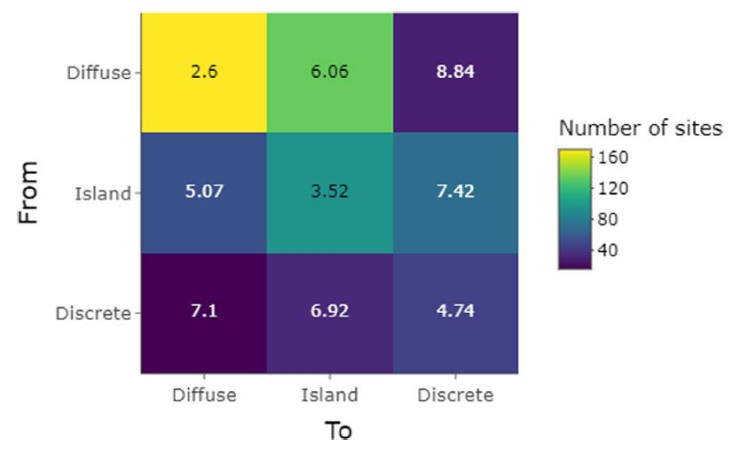

Changement de forme des lisières (1955-2015), Birre *et al.* 2023

## Chaque dimension a ses propres déterminants

Sur 94 variables candidates, 44 retenues, puis LASSO et sélection pas à pas :

| Dimension | Déterminants principaux |
| --- | --- |
| Infilling infill | Indice d’humidité topographique, exposition au vent |
| Décalage altitudinal alt | Variabilité du *sky-view factor* : hétérogénéité topographique |
| Forme forme | Composition spécifique (feuillus vs conifères), lithologie |

Trois jeux de facteurs distincts, pour trois processus distincts. Réduire la dynamique d’écotone au décalage altitudinal, c’est aussi choisir un seul jeu d’explications.

Birre, Feuillet, Milian *et al.* (2026), *Science of the Total Environment* 1013, 181318.

## Trois profils socio-environnementaux régionaux

AFM sur les variables d’environnement, puis classification. Aucune coordonnée géographique dans l’analyse — et pourtant :

### Ouest · n = 214

Basse altitude, feuillus, usage pastoral long puis déprise brutale. **Plus fortes montées**, transitions îlots ↔︎ discret.

### Centre · n = 187

Pelouses pâturées et bois pâturés, relief accumulant l’eau. **Stagnation altitudinale, infilling maximal.**

### Est · n = 225

Haute altitude, *P. uncinata*, moins accessible, usage faible. **Légères remontées, formes diffuses.**

Les trois classes se révèlent spatialement contiguës. Les effets de site ne sont pas du bruit local : ils s’organisent en régions, et ces régions sont d’abord des trajectoires d’usage.

## L’altitude module l’effet du réchauffement

Modèles additifs généralisés, interaction élévation × ΔTmax : l’interaction **non linéaire** l’emporte nettement.

Seuil objectif issu d’un mélange gaussien : **1942 m**, cohérent avec la limite montagnard / subalpin dans les Pyrénées, et avec la bascule *Fagus* → *Pinus*.

### En dessous — *Fagus sylvatica*

Décalages plus **amples**, mais faiblement liés au réchauffement : rebond forestier après déprise pastorale.

### Au-dessus — *Pinus uncinata*

Décalages plus **faibles**, mais nettement liés au réchauffement : contrainte physiologique, démographie lente.

## Même à altitude contrôlée, la relation varie dans l’espace

Régressions géographiquement pondérées robustes, une par zone et par dimension :

| Modèle | β moyen | Sites à tendance détectable |
| --- | --- | --- |
| Décalage · montagnard alt | −3,61 | 23,4 % |
| Décalage · subalpin alt | +2,36 | 16,9 % |
| Infilling · montagnard infill | −0,57 | 42,2 % |
| Infilling · subalpin infill | −1,51 | 27,9 % |

Le **signe** de l’effet du réchauffement change selon les secteurs, et les secteurs de même signe sont spatialement groupés. C’est de la non-stationnarité et non du bruit.

## Cartographie de la non-stationnarité spatiale

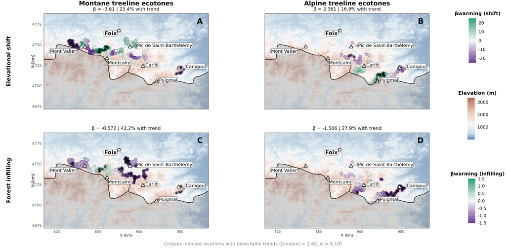

Hétérogénéité des effets du réchauffement (1955-2015) sur la dynamique de la lisière, Feuillet *et al.* 2026

## Ce qui explique cette variation : deux axes locaux

### Axe drainage

Pente et indice d’humidité. Les sites pentus et bien drainés répondent **positivement** au réchauffement ; les sites concaves et engorgés, négativement ou pas du tout.

### Axe nutriments

Substrat cristallin, sols acides et superficiels : réponses négatives. Substrat sédimentaire : réponses neutres à positives.

Sur les versants raides, deux effets se superposent : des conditions physiques favorables, et un abandon pastoral plus précoce parce que ce sont les versants les moins accessibles. Nos données ne permettent pas de les séparer.

## Biodiversité : les données acquises

### Oiseaux

**Acoustique passive**

- 192 sites
- Placettes appariées **lisière / estive**
- 21 800 heures d’enregistrement
- 94 espèces identifiées
- Écoute experte et classification BirdNET

### Papillons

**Transects standardisés**

- 105 transects
- 98 espèces identifiées
- Diversité taxonomique et fonctionnelle
- Mise en relation avec les changements climatiques et la dynamique des lisières depuis 1955

Deux groupes biologiques complémentaires pour étudier les conséquences écologiques de la dynamique des lisières.

## Biodiversité : les principaux résultats

### Oiseaux

Les espèces dominantes des lisières supérieures sont plus abondantes sur les lisières **stables** que sur les lisières progressives.

Les estives conservent leur cortège quelle que soit la dynamique de la lisière.

### Papillons

La diversité taxonomique et fonctionnelle répond conjointement :

- aux changements de température depuis 1955
- aux changements de précipitations
- au changement de forme de la lisière.

La forme de l’écotone, autant que sa position, contribue à structurer les communautés qui l’occupent.

Funosas *et al.* (2024), *Ecological Indicators* 164, 112146 · Blot (2024), mémoire de M2

# 4. Discussion

## L’importance des pratiques pastorales

Ce qu’elle contrôle :

Problème : difficulté à quantifier la pression/déprise pastorale.

Mais dès qu’on raisonne en **profils** plutôt qu’en variables, la trajectoire pastorale devient le premier discriminant entre les régions.

## Les effets de site sont aussi des jeux d’acteurs

27 entretiens auprès d’éleveurs, de gestionnaires forestiers et d’agents de réserves.

- Les éleveurs lisent la lisière comme une **ressource pastorale qui se referme**
- Les gestionnaires l’ouvrent ou la maintiennent pour des **objectifs de conservation** ciblés, le grand tétras notamment
- Entre les deux, plus d’évitement que de conflit ouvert, malgré des représentations franchement divergentes

Ces pratiques ne sont pas le contexte extérieur du processus écologique : elles en sont un déterminant, au même titre que la lithologie ou la pente.

## Synthèse

### Le climat fixe le potentiel

Il détermine où l’arbre *pourrait* pousser. Il a augmenté partout de façon comparable, et n’explique donc pas les contrastes observés.

### Les usages fixent les conditions

Des siècles d’agropastoralisme ont abaissé les lisières et modifié la composition. La déprise déclenche la recolonisation, la pression bloque tout.

### Le site module la réponse

Drainage, substrat, exposition, accessibilité : ils atténuent, amplifient, ou **inversent** l’effet du réchauffement.

D’où le titre. Ce cadre réconcilie des résultats de la littérature qui paraissaient contradictoires : ils décrivent souvent des systèmes différents, mesurés sur des dimensions différentes, à des altitudes différentes.

## Ce que nous n’avons pas pu faire

- Les **données pastorales historiques** restent fragmentaires : nous avons dû nous contenter de proxys régionaux là où il aurait fallu des charges de pâturage par estive
- Analyse **en deux dimensions seulement**, vue de dessus : ni hauteur des arbres, ni krummholz, ni âge
- **Deux dates**, donc aucune trajectoire intermédiaire ; les perturbations rapides sont invisibles
- Effectif limité en subalpin (n = 219), ce qui réduit la puissance des modèles locaux

## Ce que le projet laisse, et ce qu’il ouvre

**Acquis**

- Birre *et al.* 2023, *Landscape Ecology* — protocole de quantification des formes
- Birre *et al.* 2026, *Science of the Total Environment* — 94 déterminants, profils régionaux
- Funosas *et al.* 2024, *Ecological Indicators*
- Feuillet *et al.*, en révision à *Global Ecology and Biogeography*
- Thèse de Déborah Birre (2024)
- Base spatiale multi-échelles, plateforme cartographique publique, capsules vidéo, conventions ONF et PNR

**Suites**

- Relier **biodiversité et dynamique d’écotone** : la question secondaire devient principale => thèse de David Funosas
- Identifier des **seuils** : au-delà de quelle pression pastorale, de quel drainage, la dynamique bascule-t-elle ?
- **Simuler** plutôt que décrire : processus démographiques de *P. uncinata* à fine résolution
- Projet **ECOTONES** (2025–2026, Région Normandie et FEDER)

[tfeuillet.gitpages.huma-num.fr/spatialtreep](https://tfeuillet.gitpages.huma-num.fr/spatialtreep/) · thierry.feuillet@unicaen.fr